# Vendas de Jogos Global

Augusto Miranda

# Projeto 2VA - Analise de Dados - UFRPE

## Introdução

Este projeto visa analisar as tendências e padrões nas vendas globais de jogos de vídeo, utilizando um conjunto de dados abrangente que cataloga informações essenciais como títulos de jogos, plataformas, gêneros, e vendas regionais e globais. Ao explorar esses dados, buscamos insights valiosos sobre o comportamento do consumidor, a popularidade de diferentes gêneros de jogos, e como certas plataformas dominam ou nicham o mercado ao longo do tempo. Utilizando ferramentas poderosas do ecossistema R, como Tidyverse para manipulação de dados, DT para interatividade de tabelas, e dplyr para filtragem e agregação, este projeto não só destaca as tendências atuais no mercado de jogos, mas também fornece uma base analítica para prever futuras mudanças na indústria. Com essa análise, desenvolvedores, editores e investidores podem tomar decisões mais informadas, enquanto os entusiastas de jogos podem entender melhor as dinâmicas que moldam suas experiências de jogo. Ao final deste estudo, esperamos apresentar uma visão clara de como as vendas de jogos têm evoluído e quais fatores são mais influentes no sucesso comercial de um título, oferecendo assim uma janela para o passado, presente e possíveis futuros do entretenimento digital.

## Abordagem Metodológica

Para abordar essa análise, utilizaremos um conjunto de dados abrangente que inclui informações essenciais como títulos de jogos, plataformas, gêneros, e vendas regionais e globais. Empregaremos técnicas de análise de dados do ecossistema R, incluindo manipulação de dados com `dplyr`, visualizações com `ggplot2`, e tabelas interativas com `DT`, para investigar padrões de vendas e preferências de gênero em diferentes regiões.

## Benefícios para os Clientes

A análise proporcionará aos clientes uma visão detalhada das dinâmicas do mercado de jogos, destacando oportunidades de investimento, áreas de crescimento potencial e tendências emergentes. Desenvolvedores e editores podem usar esses insights para orientar o desenvolvimento de novos títulos, enquanto investidores e analistas de mercado podem tomar decisões mais informadas. Para os entusiastas de jogos, nossa análise oferece uma compreensão mais profunda das tendências que moldam suas experiências de jogo.

# Bibliotecas Usadas

## Bibliotecas Usadas

| Bibliotecas | Descrição |
| --- | --- |
| TidyVerse | Uma coleção de pacotes R para ciência de dados que facilita a importação, manipulação, e visualização de dados. |
| DT | Fornece uma interface R para a biblioteca JavaScript DataTables, permitindo a criação de tabelas HTML interativas. |
| dplyr | Oferece uma série de funções intuitivas para manipular dataframes, como filtrar linhas, selecionar colunas, agrupar dados e sumarizá-los, facilitando a limpeza e análise de dados. |
| ggplot2 | Permite a construção de gráficos complexos a partir de componentes simples e compreensíveis. |

## Aba 3

# Dados

## Estatísticas Descritivas

Estatísticas Descritivas das Vendas NA

| Estatistica | Vendas_NA |
| --- | --- |
| Média | 0.2646674 |
| Mediana | 0.0800000 |
| Desvio Padrão | 0.8166830 |
| Variância | 0.6669712 |
| Máximo | 41.4900000 |
| Mínimo | 0.0000000 |

Estatísticas Descritivas das Vendas EUROPA

| Estatistica | Vendas_EU |
| --- | --- |
| Média | 0.1466520 |
| Mediana | 0.0200000 |
| Desvio Padrão | 0.5053512 |
| Variância | 0.2553799 |
| Máximo | 29.0200000 |
| Mínimo | 0.0000000 |

Estatísticas Descritivas das Vendas JAPÃO

| Estatistica | Vendas_JP |
| --- | --- |
| Média | 0.0777817 |
| Mediana | 0.0000000 |
| Desvio Padrão | 0.3092906 |
| Variância | 0.0956607 |
| Máximo | 10.2200000 |
| Mínimo | 0.0000000 |

Estatísticas Descritivas das Vendas de Outros Paises

| Estatistica | Vendas_Other |
| --- | --- |
| Média | 0.0480630 |
| Mediana | 0.0100000 |
| Desvio Padrão | 0.1885884 |
| Variância | 0.0355656 |
| Máximo | 10.5700000 |
| Mínimo | 0.0000000 |

Estatísticas Descritivas das Vendas GLOBAL

| Estatistica | Vendas_GLobal |
| --- | --- |
| Média | 0.5374407 |
| Mediana | 0.1700000 |
| Desvio Padrão | 1.5550279 |
| Variância | 2.4181119 |
| Máximo | 82.7400000 |
| Mínimo | 0.0100000 |

## Gráficos

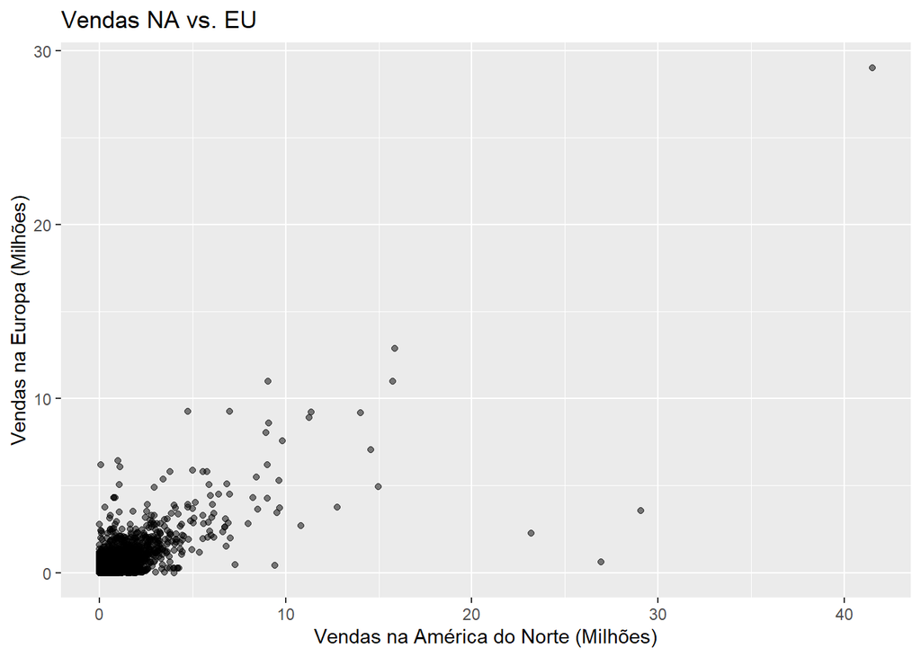

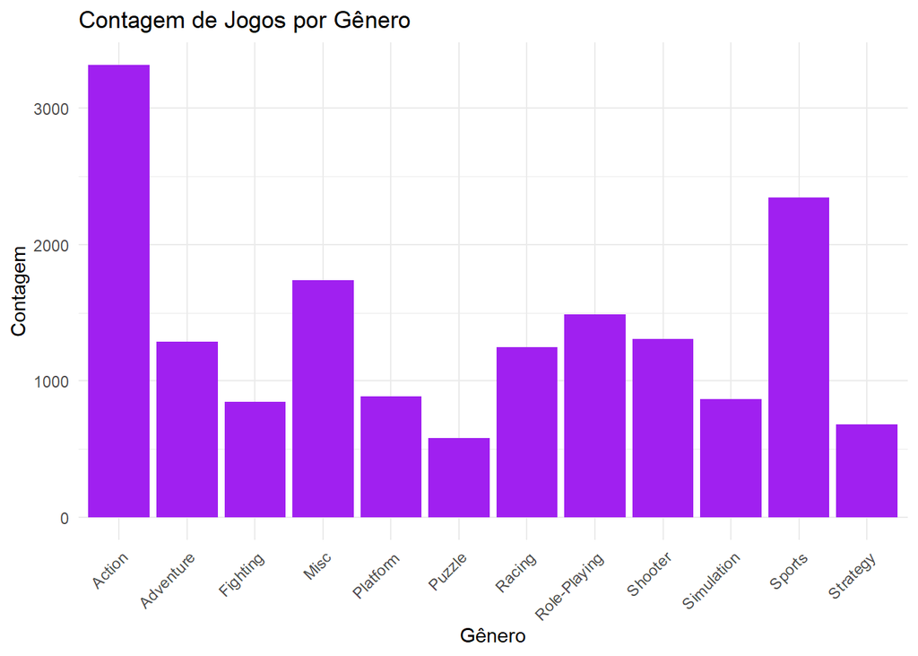

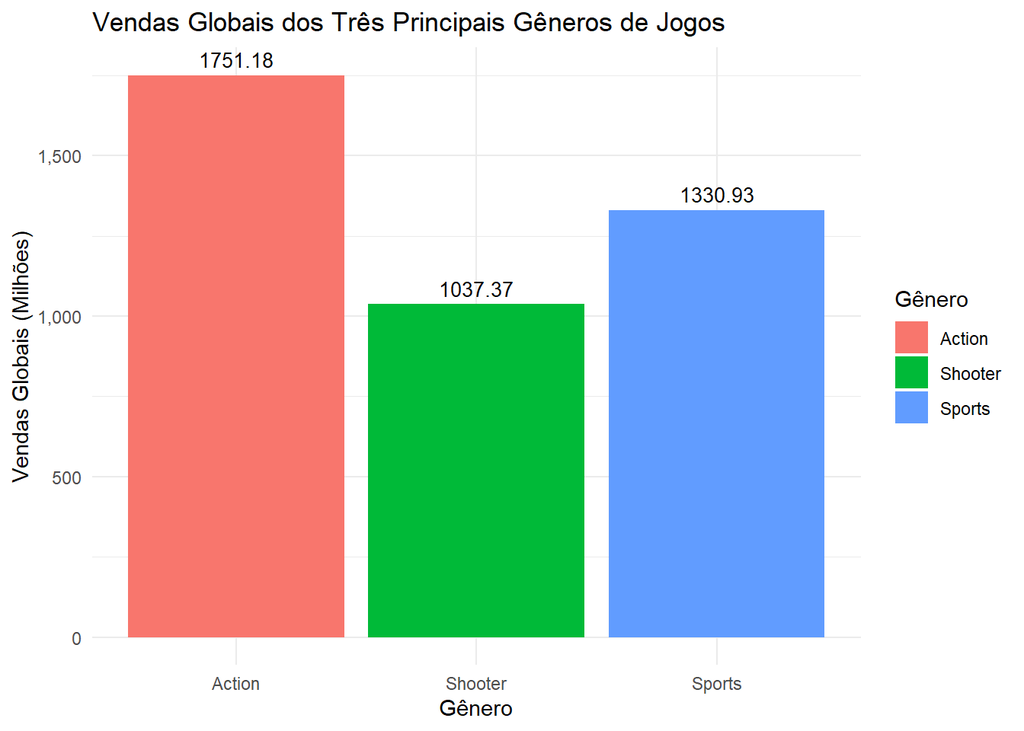

#### TOP 10 Vendas América do Norte

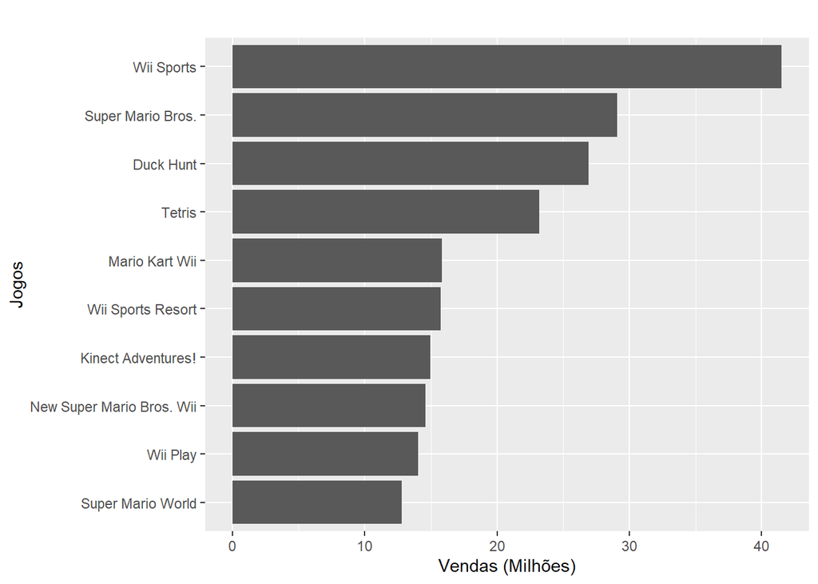

#### Vendas Globais por Plataforma

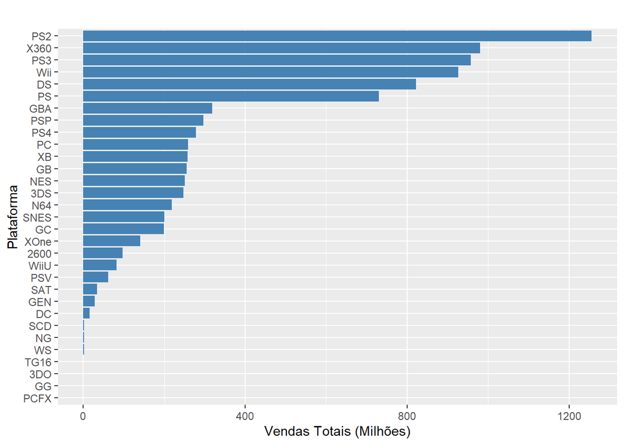

#### Vendas Globais por Gênero

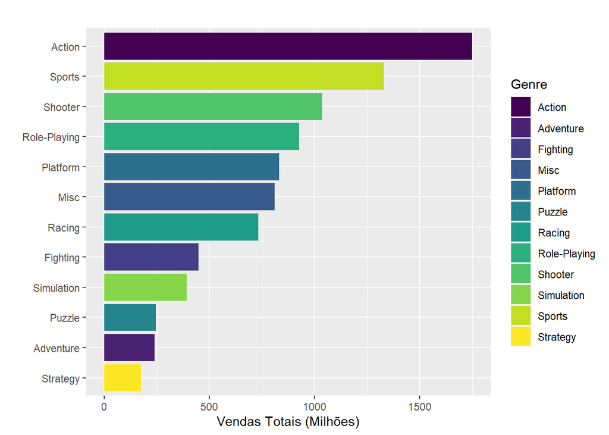

#### TOP Gêneros por Região

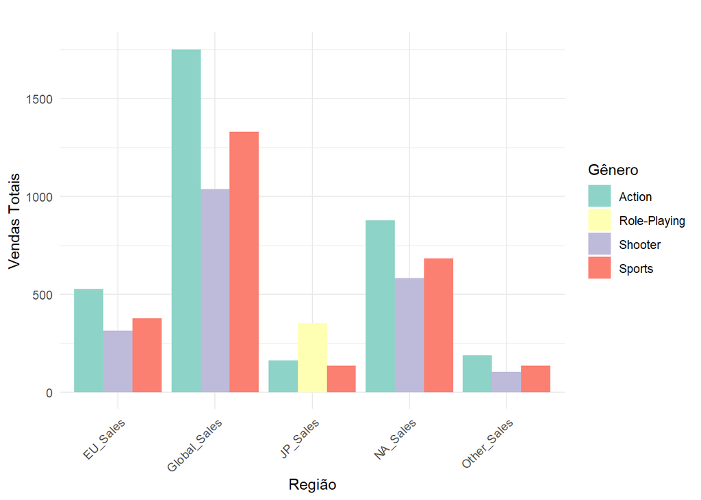

## Dados

|  | Rank | Name | Platform | Year | Genre | Publisher | NA_Sales | EU_Sales | JP_Sales | Other_Sales | Global_Sales |
| --- | --- | --- | --- | --- | --- | --- | --- | --- | --- | --- | --- |
| 1 | 1 | Wii Sports | Wii | 2006 | Sports | Nintendo | 41.49 | 29.02 | 3.77 | 8.46 | 82.74 |
| 2 | 2 | Super Mario Bros. | NES | 1985 | Platform | Nintendo | 29.08 | 3.58 | 6.81 | 0.77 | 40.24 |
| 3 | 3 | Mario Kart Wii | Wii | 2008 | Racing | Nintendo | 15.85 | 12.88 | 3.79 | 3.31 | 35.82 |
| 4 | 4 | Wii Sports Resort | Wii | 2009 | Sports | Nintendo | 15.75 | 11.01 | 3.28 | 2.96 | 33 |
| 5 | 5 | Pokemon Red/Pokemon Blue | GB | 1996 | Role-Playing | Nintendo | 11.27 | 8.89 | 10.22 | 1 | 31.37 |
| 6 | 6 | Tetris | GB | 1989 | Puzzle | Nintendo | 23.2 | 2.26 | 4.22 | 0.58 | 30.26 |
| 7 | 7 | New Super Mario Bros. | DS | 2006 | Platform | Nintendo | 11.38 | 9.23 | 6.5 | 2.9 | 30.01 |
| 8 | 8 | Wii Play | Wii | 2006 | Misc | Nintendo | 14.03 | 9.2 | 2.93 | 2.85 | 29.02 |
| 9 | 9 | New Super Mario Bros. Wii | Wii | 2009 | Platform | Nintendo | 14.59 | 7.06 | 4.7 | 2.26 | 28.62 |
| 10 | 10 | Duck Hunt | NES | 1984 | Shooter | Nintendo | 26.93 | 0.63 | 0.28 | 0.47 | 28.31 |

[output cut: 16281 more lines]